# Tidy Tuesday Jan 8 2019: TV Dramas

```r
knitr::opts_chunk$set(echo = TRUE)

library(tidyverse)
library(lubridate)
```

```r
library(ggplot2)
```

This is the first contribution to Tidy Tuesdays of Alex Danvers.

The data set contains information on TV Dramas from 1990 to 2018, including ratings, shares, and secondary categorizations of the shows.

In this document I explore changes in the common secondary classifications of dramas over time. This may give insight into the kinds of dramas that have been popular across different decades–dramas mixed with action, or with comedy, etc.

# Read in the Data

```r
# read in data
tvData <- read.csv("https://raw.githubusercontent.com/rfordatascience/tidytuesday/master/data/2019/2019-01-08/IMDb_Economist_tv_ratings.csv")

### examine basic characteristics of data
dim(tvData)
```

```
## [1] 2266    7
```

```r
head(tvData)
```

```
##     titleId seasonNumber          title       date av_rating share
## 1 tt2879552            1       11.22.63 2016-03-10    8.4890  0.51
## 2 tt3148266            1     12 Monkeys 2015-02-27    8.3407  0.46
## 3 tt3148266            2     12 Monkeys 2016-05-30    8.8196  0.25
## 4 tt3148266            3     12 Monkeys 2017-05-19    9.0369  0.19
## 5 tt3148266            4     12 Monkeys 2018-06-26    9.1363  0.38
## 6 tt1837492            1 13 Reasons Why 2017-03-31    8.4370  2.38
##                    genres
## 1    Drama,Mystery,Sci-Fi
## 2 Adventure,Drama,Mystery
## 3 Adventure,Drama,Mystery
## 4 Adventure,Drama,Mystery
## 5 Adventure,Drama,Mystery
## 6           Drama,Mystery
```

```r
# we should convert the date info from an integer to a date format
tvData$dateFormatted <- date(tvData$date)

# then we can save just the year, to simplify future viewing
tvData$year <- year(tvData$dateFormatted)

# what range does the data span?
range(tvData$dateFormatted)
```

```
## [1] "1990-01-03" "2018-10-10"
```

```r
# how many unique shows?
length(unique(tvData$title))
```

```
## [1] 868
```

```r
# how many genres?
length(unique(tvData$genres))
```

```
## [1] 97
```

```r
# 97! but this includes "combo genres"
```

The data set had a single genre variable, saved as a string, that includes multiple categorizations, separated by commas. Each TV show can have 1, 2, or 3 categorizations. This means that assessments of the secondary categorizations of TV shows are not mutually exclusive: more action shows doesn’t necessarily mean less of other shows, because the total number of secondary categories is not constant from year to year.

```r
# create list of all genres
genres <- unique(unlist(strsplit(as.character(tvData$genres), ",")))

# looping through each genre to create dummy codes
for (i in 1:length(genres)) {
  tvData[,genres[i]] <- as.numeric(grepl(genres[i], as.character(tvData$genres)))
}

# examine overall rates of all categories
colMeans(tvData[,genres])
```

```
##        Drama      Mystery       Sci-Fi    Adventure       Action
## 1.0000000000 0.2462488967 0.0679611650 0.0900264784 0.1707855252
##        Crime      Fantasy       Family      Romance       Comedy
## 0.3627537511 0.0984112974 0.0335392763 0.1037069726 0.2277140335
##     Thriller    Biography       Horror        Music        Sport
## 0.0706090026 0.0127978817 0.0547219771 0.0158870256 0.0127978817
##      History  Documentary    Animation      Western          War
## 0.0273609885 0.0017652251 0.0158870256 0.0039717564 0.0044130627
##   Reality-TV      Musical
## 0.0008826125 0.0026478376
```

```r
# save the most common secondary categories
commonCats <- which(colMeans(tvData[,genres]) > .10)

# create a data set that contains the proportion of genre by year
genreProps <- tvData %>%
  group_by(year) %>%
  summarise_at(mean, .vars=genres) %>%
  gather(key="genreCat", value="Proportion", genres[2:length(genres)])
```

# Create the Final Plot

In the plot below, we plot the change over time in common secondary categorizations of TV dramas.

A red dotted line has been placed at the 25% mark, for ease of reference.

Plots also have a black loess line superimposed on them to track the shape of the data.

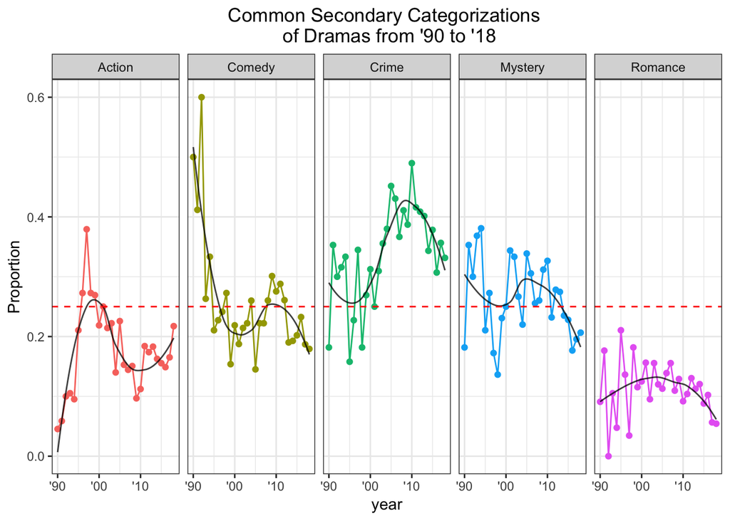

```r
ggplot(data=genreProps[which(genreProps$genreCat %in% names(commonCats)),], aes(y=Proportion, x=year))+
  geom_line(aes(color=genreCat))+
  geom_point(aes(color=genreCat))+
  geom_line(stat="smooth", method="loess", se=FALSE, color="black", lty=1, alpha=0.75)+
  theme_bw()+
  facet_grid(.~genreCat)+
  geom_hline(yintercept=0.25, lty=2, color="red")+
  theme(legend.position="none", plot.title=element_text(hjust=0.5))+
  labs(title="Common Secondary Categorizations \n of Dramas from '90 to '18")+
  scale_x_continuous(breaks=c(1990,2000,2010),
                     labels=c("'90","'00","'10"))
```

This plot suggests that drama/comedies were most common in the early 90’s, but declined to below 25% by ~95. Around 95 there was a brief spike in drama/action shows, but this trend was shortlived. From around 2000 to 2010 the number of drama/crime shows increased, but they have declined in recent years.

There was also a small rise in drama/romance shows from 1990 to ~2005, but the proportion of these shows has declined in the last decade. There were small fluctuations in the proportion of drama/mysteries over this time period, and this genre is now in decline.

Currently the most popular secondary genre for a drama is crime.